# presentation slides

Elektrauto AG

*HWR Berlin, Wintersemster 2023-2024*

*Robin Herwegh, Jasper Hadre ,Florian Liebaert*

1. Wie viele Autos wurden verkauft?

```
1.099
```

2. Was ist der Höchst-, Mindest- und Durchschnittspreis der verkauften Autos?

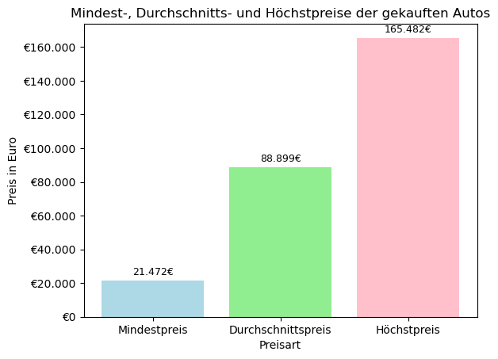

3. Wie hoch war der Gesamtumsatz?

```
97.700.084€
```

[figure not shown]

6. Haben mehr Frauen oder mehr Männer unsere Autos gekauft?

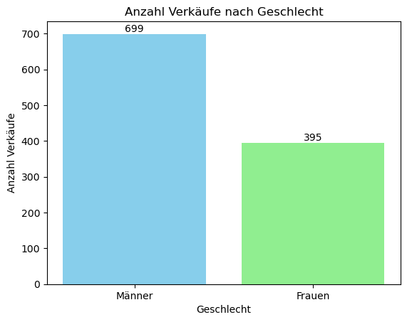

7,8,9. Wie hoch ist das Durchschnittsalter der Besucher, Kunden und männliche Kunden?

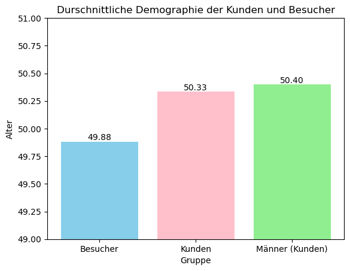

10. Wie hoch ist das Durchschnittseinkommen unserer Kunden und wie vergleicht er sich mit den Durschnittspreis der verkauften Autos?

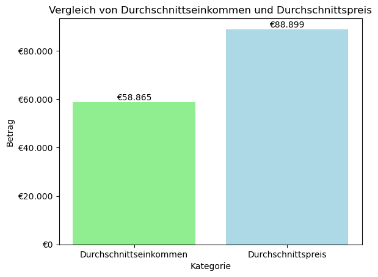

11.Wie hoch ist die Korrelation zwischen den Variablen Alter, Einkommen, Preis und Zeit für Kunden?

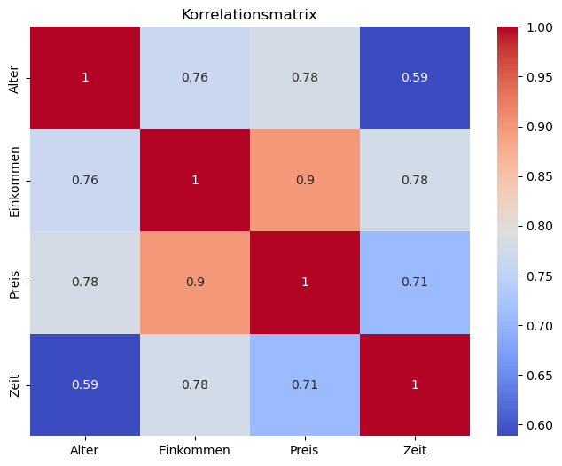

12. Wie ist die Variable Zeit verteilt?

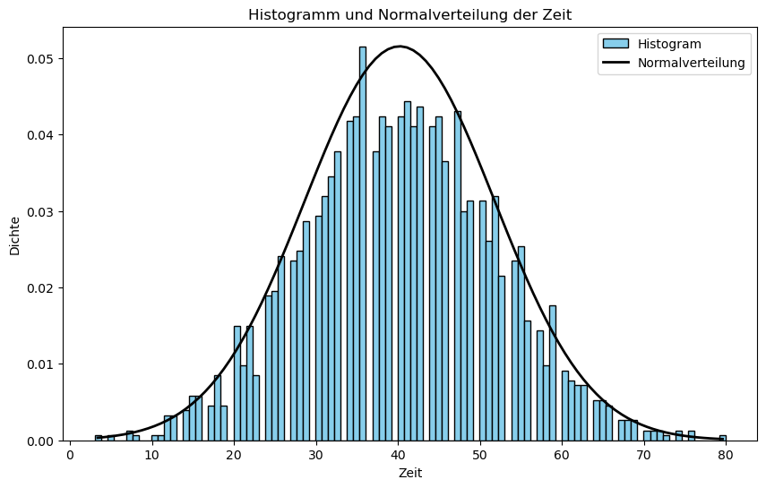

13. Wie viele Kunden haben ein Kredit bei der Bank genommen?

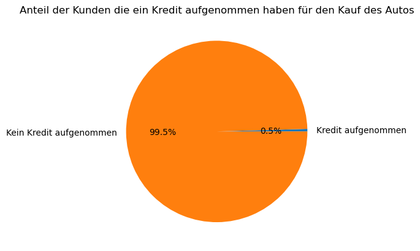

14.Sozioökonomischen Merkmale der Kunden, die den Kaufpreis beeinflussen

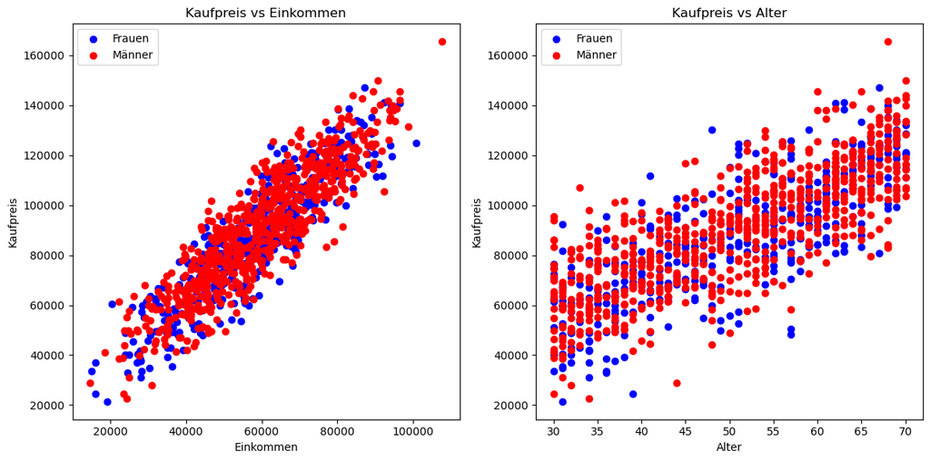

15. Prognostizierung von Kaufpreisen anhand sozioökonomischer Merkmale

Prognostizierung von dem Kaufpreis eines Autos für ein männlichen Kunde im Alter von 32 Jahren mit einem Einkommen von 30.000:

```
50.277€
```

Prognostizierung von dem Kaufpreis eines Autos für ein männlichen Kunde im Alter von 51 Jahren mit einem Einkommen von 54.000:

```
84.815€
```

16. Welche Variable beeinflusst den Preis des Autos am meisten?

```
 -> Einkommen
17522.15230204932
 -> Alter
5691.303610224638
 -> Geschlecht
1000.752843882048
Das Einkommen beeinflusst den Kaufpreis am meisten!
```

Wie haben wir die Frage beantwortet?

Question 16

# # Abhängige Variable definieren: Preis  
y3 = calculation.df_filtered2['Preis']

# Unabhängige Variablen definieren:  
X3 = calculation.df_filtered2[['Einkommen', 'Alter', 'Geschlecht']]

#Standardisieren der unabhängigen Variablenn (für standardisierte koeffizienten)  
X_scaled = scale(X3)

# Hinzufügen des Intercept für die Regression  
X_scaled = sm.add_constant(X_scaled)

#Modell aufrufen  
model3 = sm.OLS(y3, X_scaled)

# Modell fitten lassen  
results3 = model3.fit()

17,18. Kaufwahrscheinlichkeit für Auto-Modelle

Wahrscheinlichkeit, dass ein 32-jähriger männlicher Kunde mit einem Einkommen von 30.000 Euro, der das Auto 30 Minuten lang getestet hat, ein Auto kauft:

```
33%
```

Wahrscheinlichkeit, dass ein 51-jähriger männlicher Kunde mit einem Einkommen von 54.000 Euro, der das Auto 45 Minuten lang getestet hat, ein Auto kauft

```
43%
```

Wie haben wir die Koeffiziente ausgerechnet?

Frage 17

# Hinzufügen einer weiteren Spalte, 'Kauf getätigt' als Dummy Variable. Diese ist 1, wenn ein Auto gekauft wurde, und 0, wenn nicht.  
data['Kauf_getaetigt'] = data['Preis'].notna().astype(int)

# Ersetzen der NA Einträge in der Spalte Preis mit Null, da sonst alle Besucher im nächsten Schritt gelöscht werden  
data['Preis'] = data['Preis'].fillna(0)

# Löschen aller Einträge, die NA enthalten, da diese die Funktion sm.logit() stören und einen error hervorrufen  
df_filtered3 = data.dropna()

# Unabhängige Variablen (X) definieren  
X = df_filtered3[['Einkommen', 'Zeit', 'Geschlecht', 'Alter']]

# Hinzufügen einer Konstanten für den Intercept in der Regression  
X = sm.add_constant(X)

# Abhängige Variable definieren (binär)  
y = df_filtered3['Kauf_getaetigt']

# Modell aufrufen (logistisch)  
model = sm.Logit(y, X)

# Modell fitten  
results = model.fit()

# Ausgabe der logistischen Regressionskoeffizienten  
print(results.summary())

Frage 18

# Question 18 -> Errechnung der Wahrscheinlichkeiten für die beiden gegebenen Fälle  
case3 = intercept + (coefficient_alter*32) + (coefficient_einkommen*30000) + (coefficient_geschlecht*1) + (coefficient_zeit*30)  
print(case3)  
case4 = intercept + (coefficient_alter*51) + (coefficient_einkommen*54000) + (coefficient_geschlecht*1) + (coefficient_zeit*45)  
print(case4)

19. Auf welche Probleme sind Sie bei der Zusammenführung des Datensatzes gestoßen?

1. Importieren der Datensätze:

# Defining the Panda dataframe, (using "delimiter" because the csv file imports the values with a semicolon instead of a comma)  
kunden = pd.read_csv("kunden.csv", delimiter=";", index_col=5)  
besucher = pd.read_csv("besucher.csv", delimiter=";", index_col=4)

# Creating a geo.csv file from geo.txt  
geo_txt = pd.read_csv("geo.txt", delimiter= "\s+")  
geo_txt.to_csv("geo.csv", index=False)  
geo = pd.read_csv("geo.csv", index_col=0)

# Converting the , to . in the "kunden" dataframe and changing the type to integer  
kunden = kunden.replace(",", ".", regex=True)  
kunden['Einkommen'] = kunden['Einkommen'].astype(float).round().astype(int)  
print(kunden)

# Converting the , to . in the "besucher" dataframe and changing the type to integer  
besucher = besucher.replace(",", ".", regex=True)  
besucher['Einkommen'] = besucher['Einkommen'].astype(float).round().astype(int)  
print(besucher)

2. Überprüfen der Datensätze und Korigieren des Datensatzes Geo:

# Cleaning out geo:  
# 1. checking all unique values to see if there are inconsistencies  
print(geo["Niederlassung"].unique())

# 2. replacing the values so each "Bundesland" only has one value associated to it  
geo = geo.replace("NRW", "Nordrhein-Westfalen", regex=True)  
geo = geo.replace("BERLIN", "Berlin", regex=True)  
geo = geo.replace("Berlin-Charlottenburg", "Berlin", regex=True)  
geo = geo.replace("Berlin-Mitte", "Berlin", regex=True)  
geo = geo.replace("Düsseldorf", "Nordrhein-Westfalen", regex=True)

# 3. checking all unique values again to make sure all inconsistencies are fixed  
print(geo["Niederlassung"].unique())

3. Überprüfen der Datensätze und Korigieren des Datensatzes Kunden:

# Cleaning out kunden:  
# 1. checking whether there are extreme values with scatter plots:  
plt.scatter(range(len(kunden)), kunden["Alter"])  
plt.show()  
plt.clf()  
plt.scatter(range(len(kunden)), np.log(kunden["Einkommen"]))  
plt.show()  
plt.clf()  
plt.scatter(range(len(kunden)), kunden["Preis"])  
plt.show()  
plt.clf()  
plt.scatter(range(len(kunden)), kunden["Geschlecht"])  
plt.show()  
plt.clf()  
plt.scatter(range(len(kunden)), kunden["Zeit"])  
plt.show()  
plt.clf()  
# 2. We have found 2 outliers in the column "Alter" and 3 outliers in the column "Einkommen", now we will remove the outliers:  
kunden = kunden[(kunden["Alter"] < 80) & (kunden["Einkommen"] > 0) & (kunden["Einkommen"] < 1000000000)]

4. Überprüfen der Datensätze und Korigieren des Datensatzes Besucher:

# Cleaning out besucher  
# 1. checking whether there are extreme values with scatter plots:  
besucher = besucher.sort_values("KundeNr")  
plt.scatter(range(len(besucher)), besucher["Alter"])  
plt.show()  
plt.clf()

plt.scatter(range(len(besucher)), np.log(pd.to_numeric(besucher["Einkommen"])))  
plt.show()  
plt.clf()

plt.scatter(range(len(besucher)), besucher["Geschlecht"])  
plt.show()  
plt.clf()

plt.scatter(range(len(besucher)), besucher["Zeit"])  
plt.show()  
plt.clf()

# 2. Did not find any outliers. All data is cleaned

5. Zusammenführen der Datensätze und letzte Änderungen:

# Zusammenführen der Besucher und endgültigen Kunden Anhand der KundenNr  
kunden_komplett = pd.concat([besucher, kunden], ignore_index=False)  
kunden_komplett = kunden_komplett.sort_values("KundeNr")

# Umformen des Alters für spätere Berechnungen  
kunden_komplett['Alter'] = kunden_komplett['Alter'].astype(str).str.replace('\.0', '').astype(int)

# Zusammenführen aller Kunden und Geodaten anhand der Kundennummer  
df_final = pd.merge(kunden_komplett, geo, on='KundeNr', how='outer')

# "Versehentliche" Einträge ohne Informationen löschen  
df_final.dropna(subset=['Alter'], inplace=True)

# Exportieren der csv Datei für die Berechnungen  
df_final.to_csv('df_final.csv', index=True)

20. Welche Vorschläge würden Sie der Kundenabteilung für die Umfrage im nächsten Jahr machen? Welche zusätzlichen Informationen sollten gesammelt werden?

## Empfehlung für die nächste Umfrage

### Dropdown Antwortmöglichkeiten

- vermeidet das Eingeben von fehlerhaften Angaben

### Daten im einheitlichen Format erheben

- Punkte
- Komma (EU oder US Stil)

### Vergleichen mit historischen Daten

## Weitere Informationen

### Kundenpräferenzen (wichtigste Fahrzeugmerkmale)

- Leistung
- Qualität
- Größe
- Komfort
- Sicherheit

### Kundenzufriedenheit (Service/Kaufprozess)

- 1 bis 5 (sehr gut - unbefriedigend)

### Kundenberührungspunkt

- Online
- Printanzeige
- Social-Media-Marketing
- Weiterempfehlung
- Händler
- Herstellerwebseite

Vielen Dank fuer Ihre Aufmerksamkeit